# Bray Curtis Dissimilarity

gaoch

2018-10-17

本文介绍 Bray Curtis Dissimilarity 的概念和计算方法。

Bray Curtis Dissimilarity（Bray-Curtis 相异度）是生态学中用来衡量不同样地**物种组成差异**的参数。

其定义和计算公式为：

$$BC_{ij}=1-2C_{ij}/(S_{i}+S_{j})$$

## 简单的例子

有两个水族箱：

- 一号：6条金鱼，7条孔雀鱼和4只螃蟹；
- 二号：10条金鱼和6只螃蟹。

为了计算 Bray-Curtis，首先计算$C_{ij}$。金鱼两个地方都有，较少的是6；孔雀鱼只在一号中有，所以不能添加；螃蟹两个地方都有，较少的是4。因此，$C_{ij}=6+4=10$。

$S_i=6+7+4=17$，而$S_j=10+6=16$。

因此,

$$BC_{ij}=1-(2*10)/(17+16)=0.39$$

## Bray-Curtis Dissimilarity 的性质

其取值介于0-1之间。如果是0，则两个样地共享所有相同的物种；如果是1，则它们不共享任何物种。

还有另外一个 Bray-Curtis index，其取值是 1 - Bray-Curtis dissimilarity。表示两个样地之间的相似程度。

## 适用情况

要计算 Bray-Curtis Dissimilarity，必须假设两个样地的面积或体积大小相同（与物种计数相关），否则需要在计算前调整计数。

## R语言实现

`vegan`提供了`vegdist`来计算这个数值。

```r
## 用 vegdist 重复上面的例子
df <- data.frame(goldfish=c(6,10),guppies=c(7,0),crab=c(4,6))
require("vegan")
vegdist(df,method = "bray") # 这个值跟前面人脑计算的一致
```

```
##           1
## 2 0.3939394
```

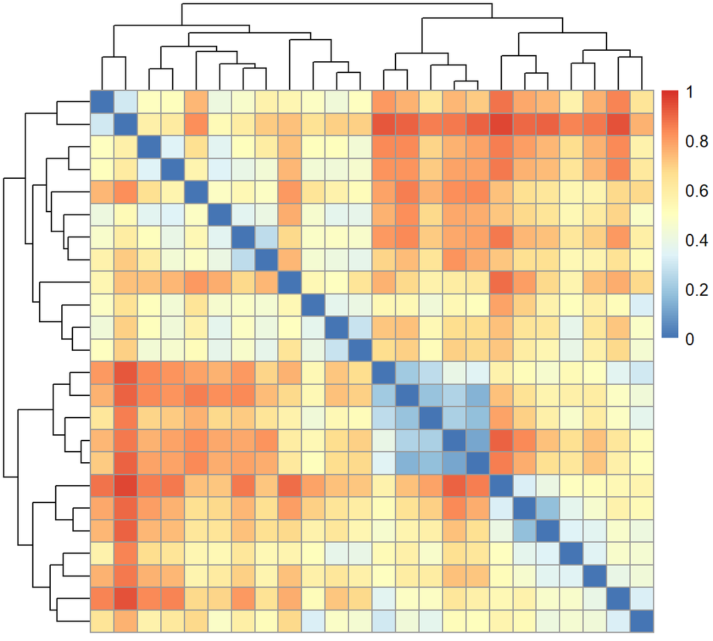

```r
## 计算群落数据
data("varespec")
## 计算不同样地两两之间的差异度
bc <- vegdist(varespec)

## 使用pheatmap做一个热图
pheatmap::pheatmap(bc,breaks = seq(0,1,0.01))
```

## 延伸阅读

`vegdist`的可用的方法（`method = "bray"`）还包括 “manhattan”, “euclidean”, “canberra”, “clark”, “bray”, “kulczynski”, “jaccard”, “gower”, “altGower”, “morisita”, “horn”, “mountford”, “raup”, “binomial”, “chao”, “cao” or “mahalanobis”。

`designdist`可用来设计自己的差异度算法。

## 参考资料

1. https://www.statisticshowto.datasciencecentral.com/bray-curtis-dissimilarity/
2. `?vegdist`